# OV organoids (Maria Vias, Brenton group)

L Morrill

2019

This file has been created from the R script with the same name

- **Important!** I believe from Geoff that Ruben has updated exposures for TCGA, BRITROC, etc. samples
- How do organoids from patients reflect the generality of OV patients?
- Given signatures of CN, can we say something about how this compares to the TCGA cohort?

Some sort of clustering of patients and organoids and see where organoids fall – based on signatures, and also based on raw CN profiles.

**To do**: for (1) signatures, and (2) CN profiles, do (1) clustering, (2) PCA (i.e. 4 plots).

(Get TCGA, ICGC, BRITROC from Geoff, and compare this to organoids).

Multisample OV: no difference of note.

*note* in latest version of signatures s1 has been removed. Additionally, now the signatures I got are not

normalised.

```r
library(grid)
library(gridExtra)
library(dendextend)
library(ggrepel)
library(cowplot)
library(compositions)
library(CompSign)
```

## 0.1 Loading data

### 0.1.1 Data from organoids

```
## Creating plot... it might take some time if the data are large. Number of samples: 18
```

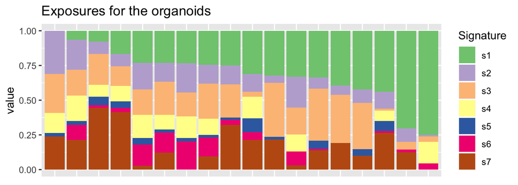

```
## Creating plot... it might take some time if the data are large. Number of samples: 18
```

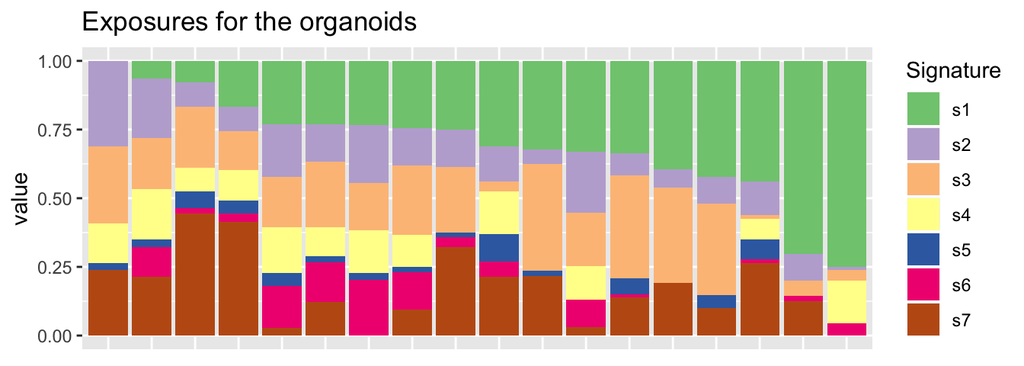

### 0.1.2 Data from Nat Gen paper

```
## Creating plot... it might take some time if the data are large. Number of samples: 51
## Creating plot... it might take some time if the data are large. Number of samples: 70
## Creating plot... it might take some time if the data are large. Number of samples: 42
## Creating plot... it might take some time if the data are large. Number of samples: 412
```

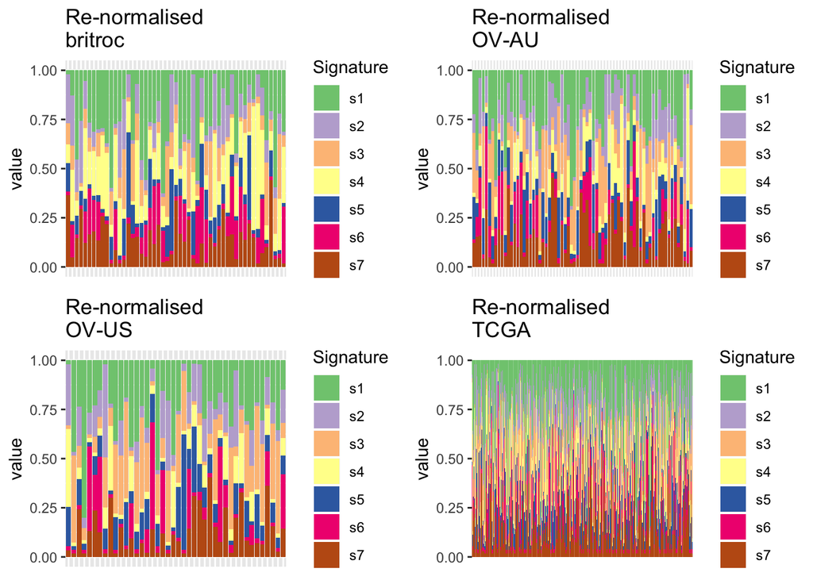

## 0.2 PCA

### 0.2.1 PCA in compositional data

In the book Analysing compositional data with R they say that PCA should be done on clr-transformed data.

Zeroes are an issue (see last section)

```r
org_barplot <- createBarplot(org, remove_labels = TRUE, order_labels = names(sort(org[,1]))) +
  ggtitle('Exposures for the organoids')
```

```
## Creating plot... it might take some time if the data are large. Number of samples: 18
```

```r
no1_natgen <- natgen_barplt1 <- createBarplot(natgen_renormalised, remove_labels = TRUE,
                                order_labels = rownames(natgen)[(order(natgen[,1]))]) +
  ggtitle('Original')
```

```
## Creating plot... it might take some time if the data are large. Number of samples: 575
```

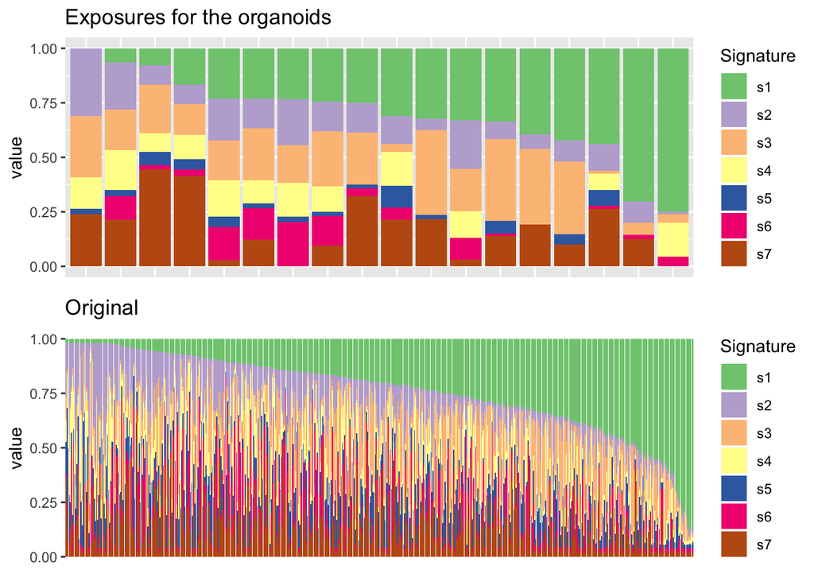

```r
grid.arrange(org_barplot, no1_natgen)
```

### 0.2.2 PCA based on the signatures

The plot done with (biplot(princomp(acomp(x)))) is the same as plotting princomp(as(clr(x), ‘matrix’))

#### 0.2.2.1 Projecting

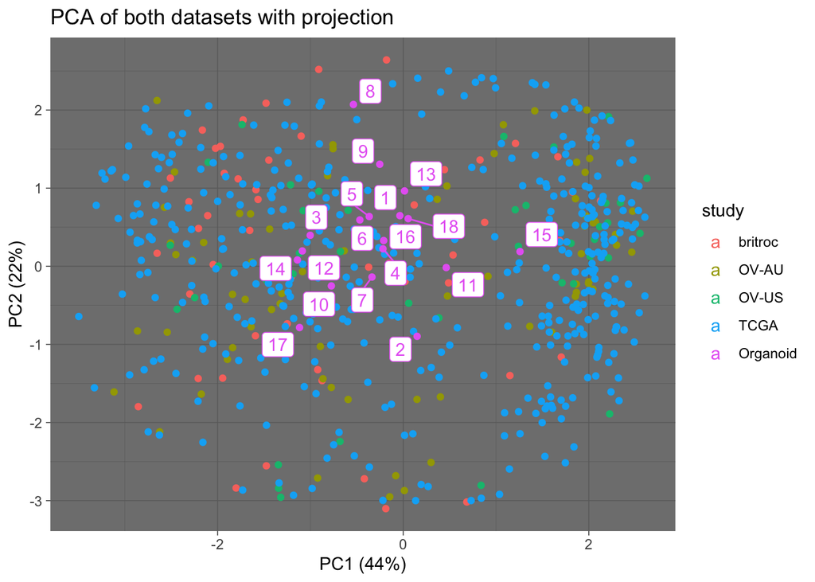

#### 0.2.2.2 What is different in these ‘underrepresented’ samples?

Conclusion: it seems as though it’s signature 3, the relative abundance of which is never high in organoid samples.

I am comparing

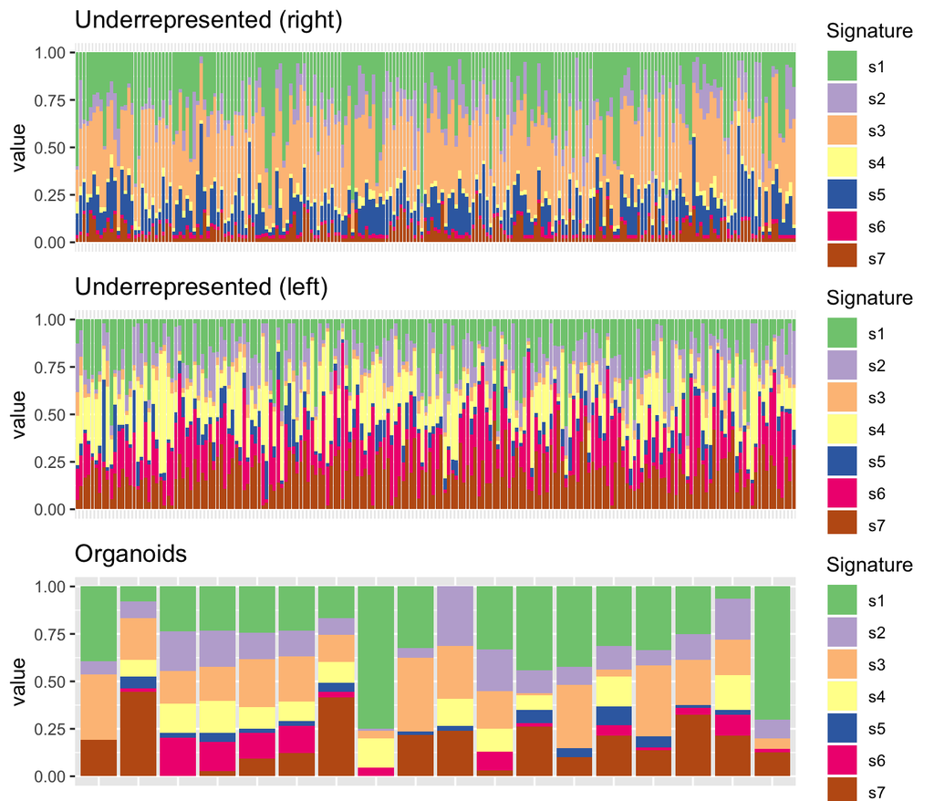

```
## Creating plot... it might take some time if the data are large. Number of samples: 209
## Creating plot... it might take some time if the data are large. Number of samples: 190
## Creating plot... it might take some time if the data are large. Number of samples: 18
```

The *ALR* is the additive log-ratio transformation, where we divide each element by one of the other elements, and then take the log

(equivalently, subtract the log of one of the parts to all other logs):

$$alr(x)_n= \Bigg(\log\Big(\frac{x_1}{x_n}\Big),\ \log\Big(\frac{x_2}{x_n}\Big), \, ..., \ \log\Big(\frac{x_{n-1}}{x_n}\Big)\Bigg)$$

Boxplots for the alr of

1. right underrepresented samples
2. left underrepresented samples
3. all samples (i.e., non-organoid) including those in (1) and (2)

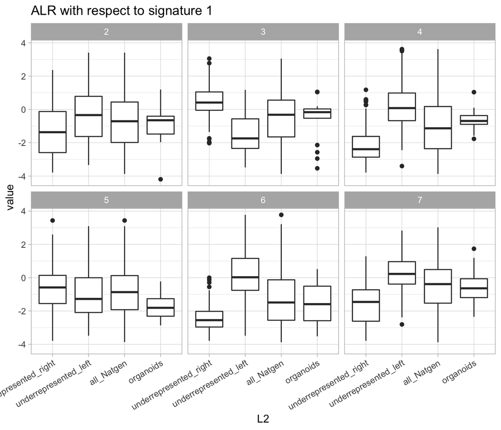

This is with the *CLR* (centered log-ratio transformation):

#’
$$clr(x)_n= \Bigg(\log\Big(\frac{x_1}{\textrm{gm}(x)}\Big),\ \log\Big(\frac{x_2}{\textrm{gm}(x)}\Big), \, ..., \ \log\Big(\frac{x_n}{\textrm{gm}(x)}\Big)\Bigg)$$

where $\textrm{gm}(x)$ is the geometric mean.

Same order:

1. right underrepresented samples
2. left underrepresented samples
3. all samples (i.e., non-organoid) including those in (1) and (2)

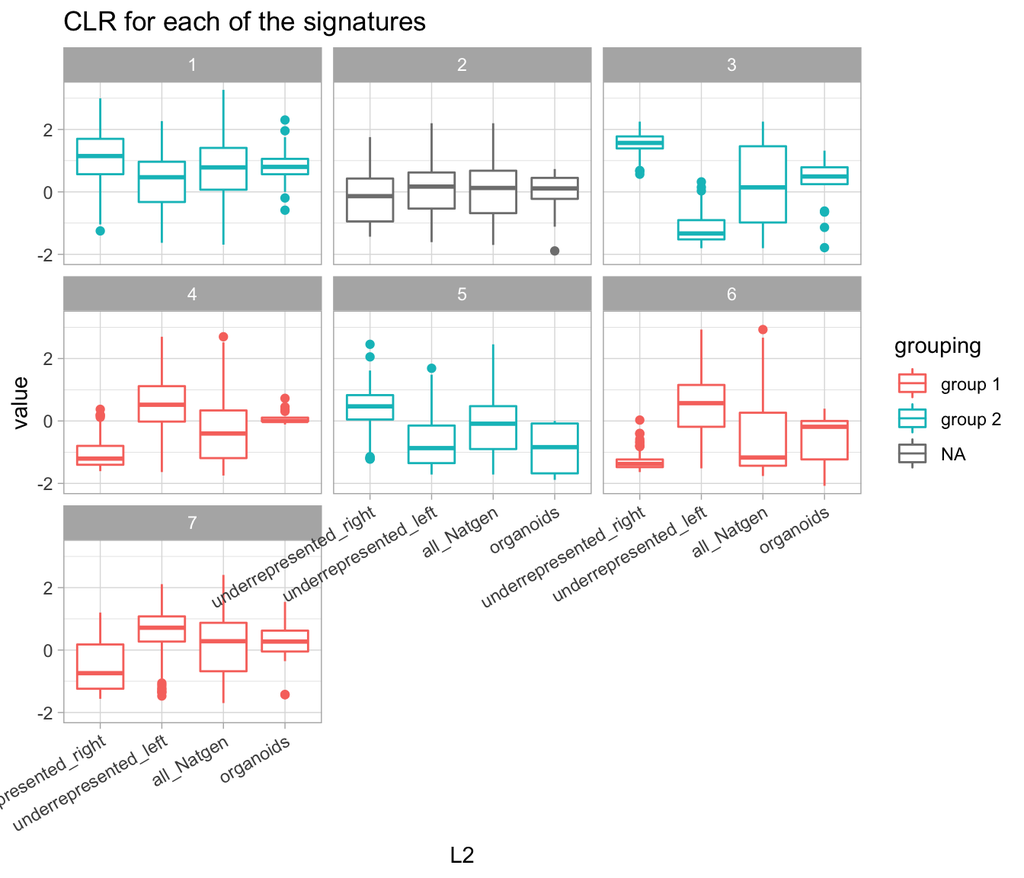

The colouring is based on some apparent patterns.

### 0.2.3 Loadings

Looking at the loadings. In particular, looking for components in the first and second PC

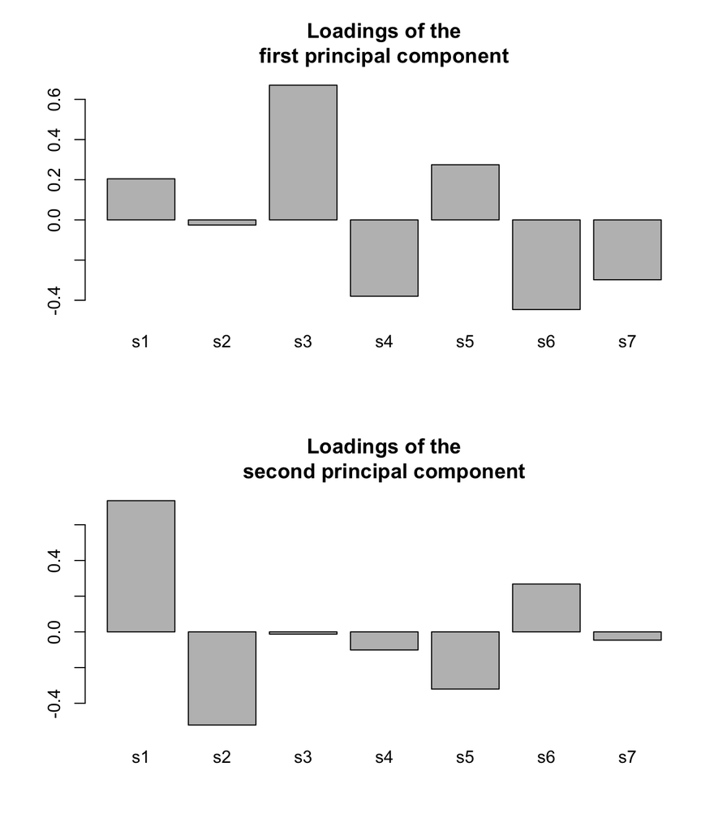

Signatures 3 and 6 seem to be quite important for the underrepresented groups

### 0.2.4 Amalgamation

Here I am amalgamating, i.e. adding together exposures

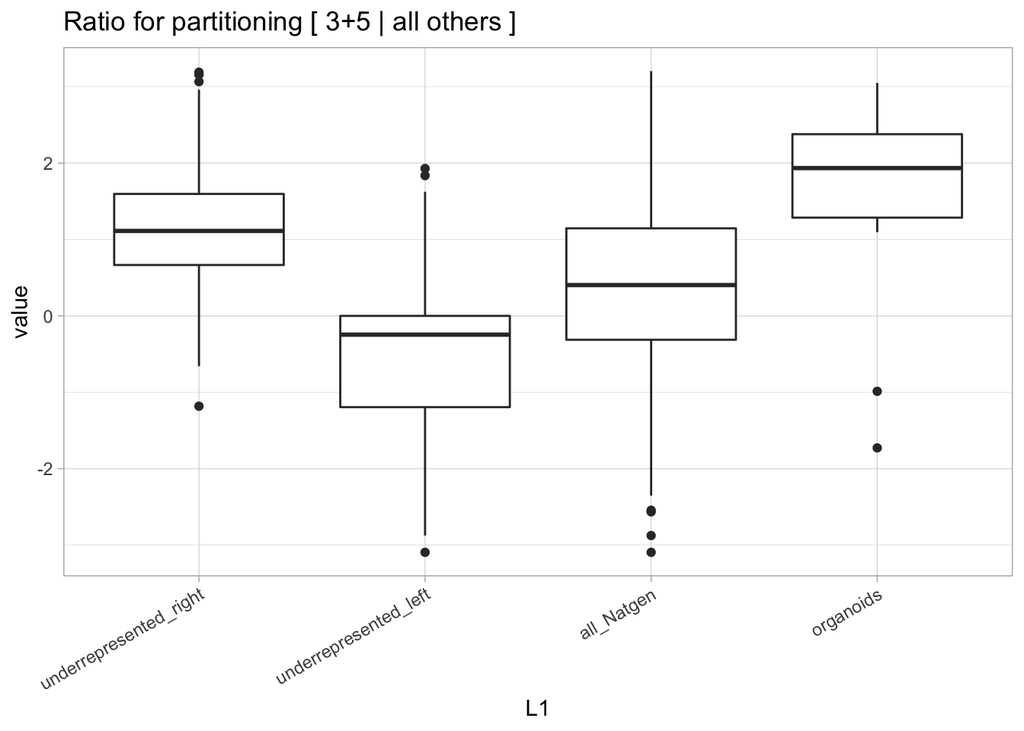

#### 0.2.4.1 Creating a new PCA

The results are basically the same

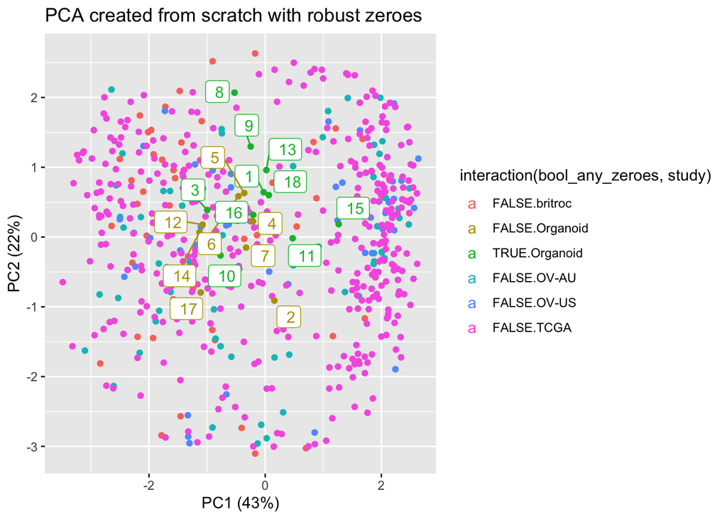

```r
## raw pca, with no compositional aspect
raw_pca_df <- createPCA_fromscratch(input_matrix = rbind(natgen_renormalised,org),
                                    annotation = c(natgen_metadata$study, rep('Organoid', nrow(org_clr))),
                                    annotation2 = c(rep(FALSE, dim(natgen_metadata)[1]), unlist(apply(org, 1, function(i) any(i == 0)))),
                                    return_df = TRUE)
## see what the vertices are
extreme_cases <- rbind(rbind(natgen,org)[which.min(raw_pca_df$Comp.2),],
       rbind(natgen,org)[which.max(raw_pca_df$Comp.2),],
       rbind(natgen,org)[which.min(raw_pca_df$Comp.1),])
rownames(extreme_cases) <- paste0('Extreme sample ', 1:3)
createBarplot(extreme_cases, remove_labels = TRUE)
```

```
## Creating plot... it might take some time if the data are large. Number of samples: 3
```

```r
bpextreme1 <- createBarplot(t(as.matrix(extreme_cases[1,])), remove_labels = TRUE)
```

```
## Creating plot... it might take some time if the data are large. Number of samples: 1
```

```r
bpextreme2 <- createBarplot(t(as.matrix(extreme_cases[2,])), remove_labels = TRUE)
```

```
## Creating plot... it might take some time if the data are large. Number of samples: 1
```

```r
bpextreme3 <- createBarplot(t(as.matrix(extreme_cases[3,])), remove_labels = TRUE)
```

```
## Creating plot... it might take some time if the data are large. Number of samples: 1
```

```r
pca_raw <- createPCA_fromscratch(input_matrix = rbind(natgen_renormalised,org),
                      annotation = c(natgen_metadata$study, rep('Organoid', nrow(org_clr))),
                      annotation2 = c(rep(FALSE, dim(natgen_metadata)[1]), unlist(apply(org, 1, function(i) any(i == 0)))), labels_active = FALSE)+
  ggtitle('PCA created from scratch without any transformation')

blankPanel<-grid.rect(gp=gpar(col="white"))
```

[figure not shown]

```r
grid.arrange(blankPanel, bpextreme2, bpextreme3, pca_raw, blankPanel, bpextreme1, ncol=2)
```

Pseudocounts analysis (not shown)

The lower the pseudocount, the more the organoid samples are left out of the PCA of all other samples.

That is because there is quite a good representation of signature landscapes in the NatGen samples, so

that anything with more non-zero exposures is likely to be represented

Conclusion: the PCA from this subcomposition is very similar to the PCA of all signatures made with robust zeroes.

Exposures from Nat Gen don’t have zeroes; for organoids many do.

### 0.2.5 PCA based on the CN profiles

To do (need to get data from Dilrini)

## 0.3 Dendrograms

### 0.3.1 Dendrogram based on the signatures

```
##  removed due to infinite values
```

```
## named integer(0)
```

```
## [1] "britroc"   "organoids" "OV-AU"     "OV-US"     "TCGA"
```

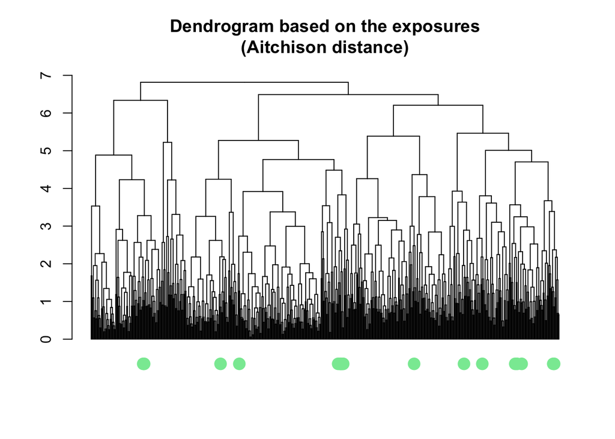

```
##
##  ●
## 18
```

### 0.3.2 Dendrogram based on the CN profiles

## 0.4 Comments

### 0.4.1 Handling of zeroes and robust zeroes

The exposures for organoids have some zero values, which is not the case for

the ones from Nature Genetics. I could either use the clr in its natural sense so that

more than half the exposures are Inf/NaN, or use the robust zeroes approach from the

package compositions.

Here I have used robust zeroes.

Below are the samples we would use if we didn’t (because they contain some zero).

```
## Organoid Sample 1, Organoid Sample 3, Organoid Sample 8, Organoid Sample 9, Organoid Sample 10, Organoid Sample 11, Organoid Sample 13, Organoid Sample 15, Organoid Sample 16, Organoid Sample 18 removed due to infinite values
```

```
##   Sample 1   Sample 2   Sample 3   Sample 4   Sample 5   Sample 6   Sample 7
## 0.16666667 0.00000000 0.05555556 0.00000000 0.00000000 0.00000000 0.00000000
##   Sample 8   Sample 9  Sample 10  Sample 11  Sample 12  Sample 13  Sample 14
## 0.11111111 0.11111111 0.11111111 0.05555556 0.00000000 0.11111111 0.00000000
##  Sample 15  Sample 16  Sample 17  Sample 18
## 0.05555556 0.05555556 0.00000000 0.11111111
```

```
##
## 1 4 5 6 7
## 1 6 4 4 2
```

More on zeroes: talk with Dom

Missingicompositions: check this section of the compositions package

ILR is with imputation

Patterns of missing signatures: 100, 101, 110, … etc

- Ilr on pseudo count means that you do a clustering on missing data
- Logistic SVD with the dichotomised matrix is the way to go!
- Signal is picked up when you dichotomise it, not with normal irl, which totally misses it

There is a laplace prior on zeroes for the Lasso

To do:

- Get ratings of signatures from Geoff
- See what sort of dats patterns there are

It’s problematic not to have any zero when you are doing the dichotomised approach

dichot <- apply(org, 2, function(i) i == 0)

dichot <- apply(dichot, 2, as.numeric)

rownames(dichot) <- rownames(org); colnames(dichot) <- colnames(org)

pheatmap(dichot, cluster_rows = FALSE, cluster_cols = FALSE)

## 0.5 Alternative transformations

Alternative transformations might deal better with zeroes.

### 0.5.1 Tsagris, Preston, and Wood (2011)

Alternative transformation of the data following section 3.2 from [this paper](https://www.tandfonline.com/doi/full/10.1080/01621459.2014.990563#aHR0cHM6Ly93d3cudGFuZGZvbmxpbmUuY29tL2RvaS9wZGYvMTAuMTA4MC8wMTYyMTQ1OS4yMDE0Ljk5MDU2Mz9uZWVkQWNjZXNzPXRydWVAQEAw)

## 0.6 CLR pairs

```
## Pseudocount of 1e-04 added
```

```
## Pseudocount of 1e-07 added
```

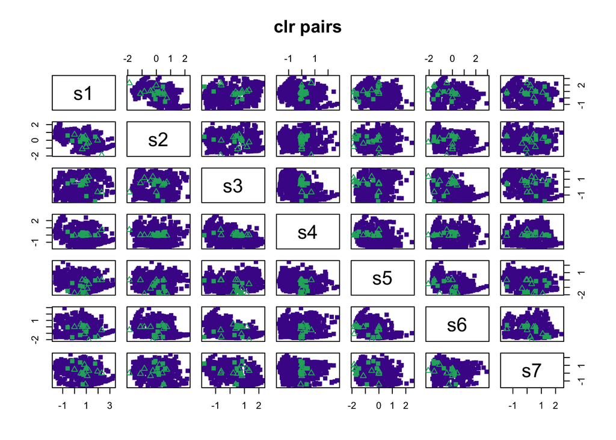

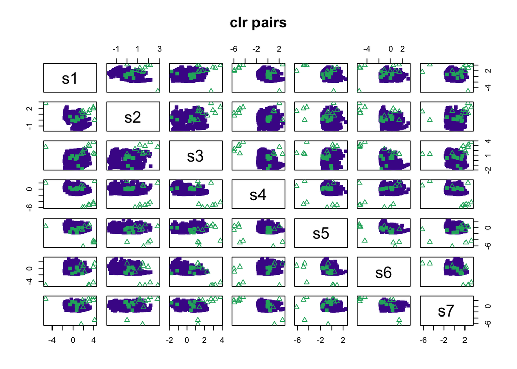

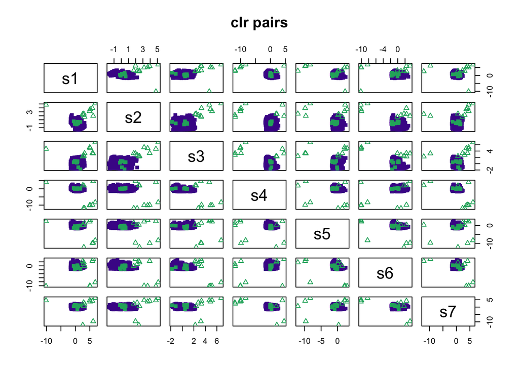